# Project: No_Show_Appointment - [Dataset-name]

# Exploring the Data (with visuals)

# Using groupby to check for the age bracket of the gender of people that didn't show up for their appointment

```python
df_no_show.groupby('gender')['age'].mean()
```

```
gender
F    36.16219
M    30.83301
Name: age, dtype: float64
```

# Graphical representation of the age bracket of the gender of people that did'nt show up for their Appointment.

```python
def bar(data):
    data.plot(kind = 'bar', alpha = 0.9,figsize = (10,8));
```

```python
age = df_no_show.groupby('gender')['age'].mean()
```

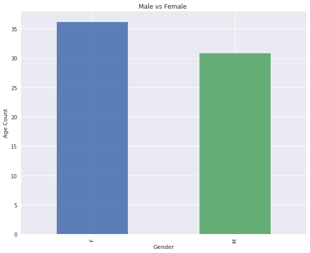

```python
bar(age)
plt.title('Male vs Female ')
plt.xlabel('Gender')
plt.ylabel('Age Count');
```

```python
df_no_show.columns
```

```
Index(['age', 'gender', 'appointmentday', 'neighbourhood', 'scholarship',
       'hipertension', 'diabetes', 'alcoholism', 'handcap', 'sms_received',
       'no_show'],
      dtype='object')
```

# Research Question 1 (Was it because they don't have scholarship? Are there more male or female that do not have Scholarship?)

```python
# Checking for the number of male and female that did'nt show up for their appointment due to not having Scholarship.
df_no_show.groupby('gender')['scholarship'].value_counts()
```

```
gender  scholarship
F       0              12488
        1               2106
M       0               7253
        1                472
Name: scholarship, dtype: int64
```

```python
# Graphical representaion of male and female that did'nt show up for their appointment due to not having Scholarship
scholarship = df_no_show.groupby('gender')['scholarship'].value_counts()
```

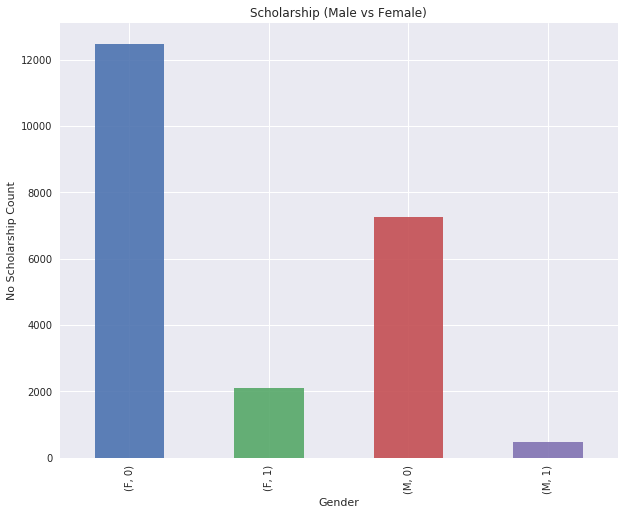

```python
bar(scholarship)
plt.title('Scholarship (Male vs Female)')
plt.xlabel('Gender')
plt.ylabel('No Scholarship Count');
```

# Checking for the percentage of each of the gender in the dataset to know the number of a specific gender(male or female) that didnt show up for their appointment and reasons for them not showing up mostly.

```python
df_no_show['gender'].value_counts(normalize = True)
```

```
F    0.653882
M    0.346118
Name: gender, dtype: float64
```

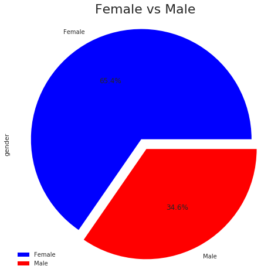

```python
# Graphical representation of the percentage of each of the gender in the dataset to know the number of a specific
# gender(male or female) that didnt show up for their appointment and reasons for them not showing up mostly.
labels = ['Female', 'Male']
colors = ['blue', 'red']
explode = (0, 0.1)
df_no_show['gender'].value_counts(normalize = True).plot(explode=explode, labels=labels, colors=colors, autopct='%1.1f%%',figsize = (8,8),kind = 'pie');
plt.title(' Female vs Male',fontsize=22)
plt.axis('equal')
fig = plt.gcf()
plt.legend();
```